# EASYVISA

## **Context**

Business communities in the United States are facing high demand for human resources, but one of the constant challenges is identifying and attracting the right talent, which is perhaps the most important element in remaining competitive. Companies in the United States look for hard-working, talented, and qualified individuals both locally as well as abroad.

The Immigration and Nationality Act (INA) of the US permits foreign workers to come to the United States to work on either a temporary or permanent basis. The act also protects US workers against adverse impacts on their wages or working conditions by ensuring US employers' compliance with statutory requirements when they hire foreign workers to fill workforce shortages. The immigration programs are administered by the Office of Foreign Labor Certification (OFLC).

OFLC processes job certification applications for employers seeking to bring foreign workers into the United States and grants certifications in those cases where employers can demonstrate that there are not sufficient US workers available to perform the work at wages that meet or exceed the wage paid for the occupation in the area of intended employment.

## **Objective**

In FY 2016, the OFLC processed 775,979 employer applications for 1,699,957 positions for temporary and permanent labor certifications. This was a nine percent increase in the overall number of processed applications from the previous year. The process of reviewing every case is becoming a tedious task as the number of applicants is increasing every year.

The increasing number of applicants every year calls for a Machine Learning based solution that can help shortlist candidates with higher chances of VISA approval. OFLC has hired the firm EasyVisa for data-driven solutions. You as a data scientist at EasyVisa have to analyze the data provided and, with the help of a classification model:

Facilitate the process of visa approvals. Recommend a suitable profile for the applicants for whom the visa should be certified or denied based on the drivers that significantly influence the case status.

## **Data Description**

The data contains the different attributes of the employee and the employer. The detailed data dictionary is given below.

- `case_id` : ID of each visa application
- `continent` : Information of continent the employee
- `education_of_employee` : Information of education of the employee
- `has_job_experience` : Does the employee have any job experience? Y= Yes; N = No
- `requires_job_training` : Does the employee require any job training? Y = Yes; N = No
- `no_of_employees` : Number of employees in the employer's company
- `yr_of_estab` : Year in which the employer's company was established
- `region_of_employment` : Information of foreign worker's intended region of employment in the US.
- `prevailing_wage` : Average wage paid to similarly employed workers in a specific occupation in the area of intended employment. The purpose of the prevailing wage is to ensure that the foreign worker is not underpaid compared to other workers offering the same or similar service in the same area of employment.
- `unit_of_wage` : Unit of prevailing wage. Values include Hourly, Weekly, Monthly, and Yearly.
- `full_time_position` : Is the position of work full-time? Y = Full-Time Position; N = Part-Time Position
- `case_status` : Flag indicating if the Visa was certified or denied

## **Importing necessary libraries and data**

```python
#libraries to read and manipulate data
import numpy as np
import pandas as pd

#libraries to visualize data
import matplotlib.pyplot as plt
import seaborn as sns

#libraries for model building and tuning
from sklearn import tree
from sklearn.tree import DecisionTreeClassifier
from sklearn.ensemble import (BaggingClassifier,RandomForestClassifier,
                              GradientBoostingClassifier, AdaBoostClassifier)
from xgboost import XGBClassifier
from sklearn.model_selection import train_test_split
from sklearn.model_selection import GridSearchCV, RandomizedSearchCV

#libraries for metrics and statistics
from sklearn import metrics
import scipy.stats as stats
from sklearn.metrics import confusion_matrix, classification_report
from sklearn.metrics import accuracy_score,precision_score,recall_score,f1_score, roc_auc_score

import warnings
warnings.filterwarnings('ignore')
```

## Data Overview

```python
from google.colab import drive
drive.mount('/content/drive')
```

```python
data = pd.read_csv("/content/drive/MyDrive/AIML/Ensemble_Techniques/EasyVisa.csv")
```

```python
df = data.copy()
```

**First and last 5 rows of the dataset**

```python
# looking at head (first 5 observations)
df.head()
```

|  | case_id | continent | education_of_employee | has_job_experience | requires_job_training | no_of_employees | yr_of_estab | region_of_employment | prevailing_wage | unit_of_wage | full_time_position | case_status |
| --- | --- | --- | --- | --- | --- | --- | --- | --- | --- | --- | --- | --- |
| 0 | EZYV01 | Asia | High School | N | N | 14513 | 2007 | West | 592.2029 | Hour | Y | Denied |
| 1 | EZYV02 | Asia | Master's | Y | N | 2412 | 2002 | Northeast | 83425.6500 | Year | Y | Certified |
| 2 | EZYV03 | Asia | Bachelor's | N | Y | 44444 | 2008 | West | 122996.8600 | Year | Y | Denied |
| 3 | EZYV04 | Asia | Bachelor's | N | N | 98 | 1897 | West | 83434.0300 | Year | Y | Denied |
| 4 | EZYV05 | Africa | Master's | Y | N | 1082 | 2005 | South | 149907.3900 | Year | Y | Certified |

```python
# looking at tail (last 5 observations)
df.tail()
```

|  | case_id | continent | education_of_employee | has_job_experience | requires_job_training | no_of_employees | yr_of_estab | region_of_employment | prevailing_wage | unit_of_wage | full_time_position | case_status |
| --- | --- | --- | --- | --- | --- | --- | --- | --- | --- | --- | --- | --- |
| 25475 | EZYV25476 | Asia | Bachelor's | Y | Y | 2601 | 2008 | South | 77092.57 | Year | Y | Certified |
| 25476 | EZYV25477 | Asia | High School | Y | N | 3274 | 2006 | Northeast | 279174.79 | Year | Y | Certified |
| 25477 | EZYV25478 | Asia | Master's | Y | N | 1121 | 1910 | South | 146298.85 | Year | N | Certified |
| 25478 | EZYV25479 | Asia | Master's | Y | Y | 1918 | 1887 | West | 86154.77 | Year | Y | Certified |
| 25479 | EZYV25480 | Asia | Bachelor's | Y | N | 3195 | 1960 | Midwest | 70876.91 | Year | Y | Certified |

```python
#Checking the shape of the dataset
df.shape
```

```
(25480, 12)
```

- There are 25480 row and 12 column present in dataset.

```python
#Checking the data types of the columns for the dataset
df.info()
```

```
<class 'pandas.core.frame.DataFrame'>
RangeIndex: 25480 entries, 0 to 25479
Data columns (total 12 columns):
 #   Column                 Non-Null Count  Dtype
---  ------                 --------------  -----
 0   case_id                25480 non-null  object
 1   continent              25480 non-null  object
 2   education_of_employee  25480 non-null  object
 3   has_job_experience     25480 non-null  object
 4   requires_job_training  25480 non-null  object
 5   no_of_employees        25480 non-null  int64
 6   yr_of_estab            25480 non-null  int64
 7   region_of_employment   25480 non-null  object
 8   prevailing_wage        25480 non-null  float64
 9   unit_of_wage           25480 non-null  object
 10  full_time_position     25480 non-null  object
 11  case_status            25480 non-null  object
dtypes: float64(1), int64(2), object(9)
memory usage: 2.3+ MB
```

- Most of the features are object data type except no of employees and yr of estab are in int64 format as well prevailing wage is in float.
- Case status is our target variable.
- There seems to be no missing values for any of these columns

```python
#checking for duplicates
df.duplicated().sum()
```

```
0
```

- There are no missing values present in given dataset.

```python
df.isna().sum()
```

|  | 0 |
| --- | --- |
| case_id | 0 |
| continent | 0 |
| education_of_employee | 0 |
| has_job_experience | 0 |
| requires_job_training | 0 |
| no_of_employees | 0 |
| yr_of_estab | 0 |
| region_of_employment | 0 |
| prevailing_wage | 0 |
| unit_of_wage | 0 |
| full_time_position | 0 |
| case_status | 0 |

**dtype:** int64

```python
df.describe().T
```

|  | count | mean | std | min | 25% | 50% | 75% | max |
| --- | --- | --- | --- | --- | --- | --- | --- | --- |
| no_of_employees | 25480.0 | 5667.043210 | 22877.928848 | -26.0000 | 1022.00 | 2109.00 | 3504.0000 | 602069.00 |
| yr_of_estab | 25480.0 | 1979.409929 | 42.366929 | 1800.0000 | 1976.00 | 1997.00 | 2005.0000 | 2016.00 |
| prevailing_wage | 25480.0 | 74455.814592 | 52815.942327 | 2.1367 | 34015.48 | 70308.21 | 107735.5125 | 319210.27 |

- There are 25480 number of employee data present in directory.
- The oldest company estabilished in 1800 and latest one is in 2016.
- The prevailing wage mean, minimum and max is 74455.81, 2.13 and 319210.27 respectively.

```python
df.describe(include="object").T
```

|  | count | unique | top | freq |
| --- | --- | --- | --- | --- |
| case_id | 25480 | 25480 | EZYV01 | 1 |
| continent | 25480 | 6 | Asia | 16861 |
| education_of_employee | 25480 | 4 | Bachelor's | 10234 |
| has_job_experience | 25480 | 2 | Y | 14802 |
| requires_job_training | 25480 | 2 | N | 22525 |
| region_of_employment | 25480 | 5 | Northeast | 7195 |
| unit_of_wage | 25480 | 4 | Year | 22962 |
| full_time_position | 25480 | 2 | Y | 22773 |
| case_status | 25480 | 2 | Certified | 17018 |

- Above insights gives descriptive overview about the object data type.

```python
df.drop("case_id", axis = 1, inplace = True)
```

- Case id is unique number for empolyee identification and its not contibute during model building so we have dropped this.

## **Exploratory Data Analysis (EDA)**

```python
# function to create labeled barplots

def labeled_barplot(data, feature, feature_2, order, perc=False, n=None):
    """
    Barplot with percentage at the top

    data: dataframe
    feature: dataframe column
    feature_2: dataframe column
    perc: whether to display percentages instead of count (default is False)
    n: displays the top n category levels (default is None, i.e., display all levels)
    """

    total = len(data[feature])  # length of the column
    count = data[feature].nunique()
    if n is None:
        plt.figure(figsize=(count + 1, 5))
    else:
        plt.figure(figsize=(n + 1, 5))

    plt.xticks(rotation=90)
    ax = sns.countplot(
        data=data,
        x=feature,
        palette='coolwarm',
        order=order,
        hue=feature_2,
    )

    for p in ax.patches:
        if perc == True:
            label = "{:.1f}%".format(
                100 * p.get_height() / total
            )  # percentage of each class of the category
        else:
            label = p.get_height()  # count of each level of the category

        x = p.get_x() + p.get_width() / 2  # width of the plot
        y = p.get_height()  # height of the plot

        ax.annotate(
            label,
            (x, y),
            ha="center",
            va="center",
            size=9,
            xytext=(0, 5),
            textcoords="offset points"
        )  # annotate the percentage

    plt.show()  # show the plot
```

```python
# function to plot a boxplot and a histogram along the same scale

def histogram_boxplot(data, feature, figsize=(16, 6), kde=False, bins=None, hue=None):
    """
    Combines boxplot and histogram

    data: dataframe
    feature: dataframe column
    figsize: size of figure (default (16,6))
    kde: whether to show the density curve (default False)
    bins: number of bins for histogram (default None)
    """
    f2, (ax_box2, ax_hist2) = plt.subplots(
        nrows=2,  # Number of rows of the subplot grid= 2
        sharex=True,  # x-axis will be shared among all subplots
        gridspec_kw={"height_ratios": (0.25, 0.75)},
        figsize=figsize,
    )  # creating the 2 subplots
    sns.boxplot(
        data=data, x=feature, ax=ax_box2, showmeans=True,
    )  # boxplot will be created and a star will indicate the mean value of the column
    sns.histplot(
        data=data, x=feature, kde=kde, ax=ax_hist2, bins=bins, palette="winter",
    ) if bins else sns.histplot(
        data=data, x=feature, kde=kde, ax=ax_hist2
    )  # For histogram
    ax_hist2.axvline(
        data[feature].mean(), color="green", linestyle="--"
    )  # Add mean to the histogram
    ax_hist2.axvline(
        data[feature].median(), color="black", linestyle="-"
    )  # Add median to the histogram
```

```python
### function to plot distributions wrt target


def distribution_plot_wrt_target(data, predictor, target):

    fig, axs = plt.subplots(2, 2, figsize=(12, 10))

    target_uniq = data[target].unique()

    axs[0, 0].set_title("Distribution of target for target=" + str(target_uniq[0]))
    sns.histplot(
        data=data[data[target] == target_uniq[0]],
        x=predictor,
        kde=True,
        ax=axs[0, 0],
        color="teal",
        stat="density",
    )

    axs[0, 1].set_title("Distribution of target for target=" + str(target_uniq[1]))
    sns.histplot(
        data=data[data[target] == target_uniq[1]],
        x=predictor,
        kde=True,
        ax=axs[0, 1],
        color="orange",
        stat="density",
    )

    axs[1, 0].set_title("Boxplot w.r.t target")
    sns.boxplot(data=data, x=target, y=predictor, ax=axs[1, 0], palette="gist_rainbow")

    axs[1, 1].set_title("Boxplot (without outliers) w.r.t target")
    sns.boxplot(
        data=data,
        x=target,
        y=predictor,
        ax=axs[1, 1],
        showfliers=False,
        palette="gist_rainbow",
    )

    plt.tight_layout()
    plt.show()
```

1. Those with higher education may want to travel abroad for a well-paid job. Does education play a role in Visa certification?

```python
df.groupby("education_of_employee")["case_status"].value_counts()
```

| education_of_employee | case_status | count |
| --- | --- | --- |
| Bachelor's | Certified | 6367 |
|  | Denied | 3867 |
| Doctorate | Certified | 1912 |
|  | Denied | 280 |
| High School | Denied | 2256 |
|  | Certified | 1164 |
| Master's | Certified | 7575 |
|  | Denied | 2059 |

**dtype:** int64

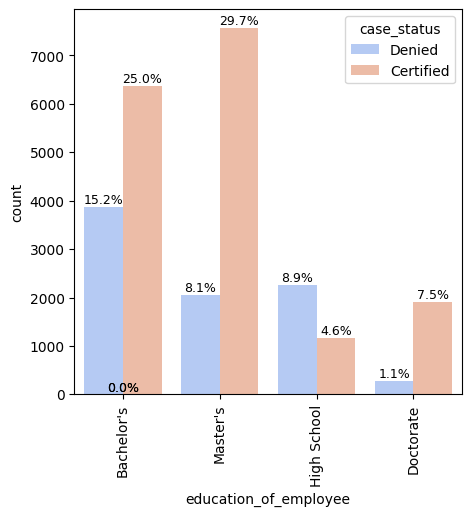

```python
labeled_barplot(df, "education_of_employee", "case_status", order=df["education_of_employee"].value_counts().index, perc = True)
```

- As the graph aboves shows, the ratio of applications being certified versus denied increases considerably as an applicant's highest level of education achieved increases.
- The ratio of an applicant with a high school diploma being approved versus denied is ~1:2, whereas the same ratio for an applicant with a doctorate is ~7:1.
1. How does the visa status vary across different continents?

```python
df.groupby("continent")["case_status"].value_counts()
```

| continent | case_status | count |
| --- | --- | --- |
| Africa | Certified | 397 |
|  | Denied | 154 |
| Asia | Certified | 11012 |
|  | Denied | 5849 |
| Europe | Certified | 2957 |
|  | Denied | 775 |
| North America | Certified | 2037 |
|  | Denied | 1255 |
| Oceania | Certified | 122 |
|  | Denied | 70 |
| South America | Certified | 493 |
|  | Denied | 359 |

**dtype:** int64

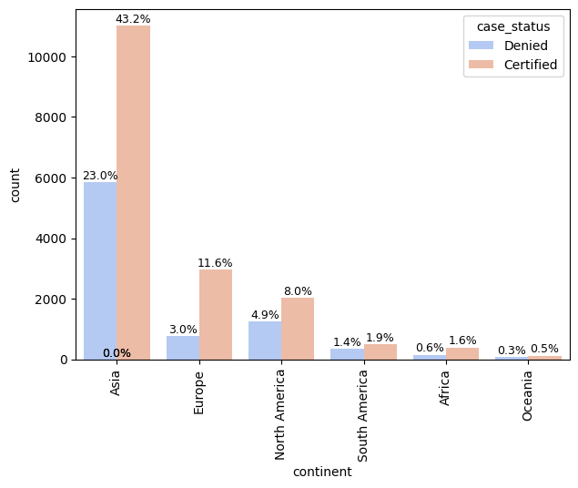

```python
labeled_barplot(df, "continent", "case_status", order=df["continent"].value_counts().index, perc = True)
```

- Applicants from Asia comprise ~2/3 of all applications and these applicants have almost a 2:1 ratio of approvals to denials.
- An application from a European applicant has the best ratio of approvals to denials (~4:1).
1. Experienced professionals might look abroad for opportunities to improve their lifestyles and career development. Does work experience influence visa status?

```python
df.groupby("has_job_experience")["case_status"].value_counts()
```

| has_job_experience | case_status | count |
| --- | --- | --- |
| N | Certified | 5994 |
|  | Denied | 4684 |
| Y | Certified | 11024 |
|  | Denied | 3778 |

**dtype:** int64

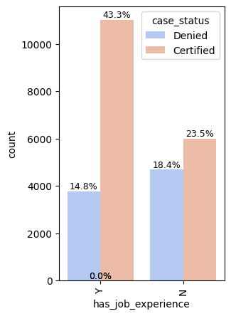

```python
labeled_barplot(df, "has_job_experience", "case_status", order=df["has_job_experience"].value_counts().index, perc = True)
```

- Applicants with job experience have a ratio of approved to denied applications of ~3:1, whereas the same ratio for applicants without job experience have around a 5:4 ratio (i.e., approximately equivalent).
1. In the United States, employees are paid at different intervals. Which pay unit is most likely to be certified for a visa?

```python
df.groupby("unit_of_wage")["case_status"].value_counts()
```

| unit_of_wage | case_status | count |
| --- | --- | --- |
| Hour | Denied | 1410 |
|  | Certified | 747 |
| Month | Certified | 55 |
|  | Denied | 34 |
| Week | Certified | 169 |
|  | Denied | 103 |
| Year | Certified | 16047 |
|  | Denied | 6915 |

**dtype:** int64

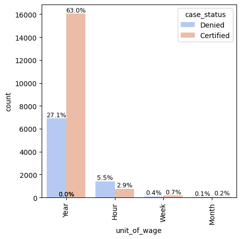

```python
labeled_barplot(df, "unit_of_wage", "case_status", order=df["unit_of_wage"].value_counts().index, perc = True)
```

- Applicants who are applying to work in a job with an hourly rate have a ratio of approved versus denied applications of ~1:2. Additionally, these applicants comprise only ~8% of all applications, but comprise ~17% of all denials.
- Applicants from any other unit_of_wage category have a ratio of ~2:1, with applications for jobs with annual salaries showing nearly a 2.5:1 ratio of approvals to denials.
1. The US government has established a prevailing wage to protect local talent and foreign workers. How does the visa status change with the prevailing wage?

```python
#group data by unit_of_wage and calculate the mean prevailing_wage for each category
df.groupby('unit_of_wage')['prevailing_wage'].mean()
```

| unit_of_wage | prevailing_wage |
| --- | --- |
| Hour | 414.570513 |
| Month | 87592.864045 |
| Week | 85606.820515 |
| Year | 81228.077133 |

**dtype:** float64

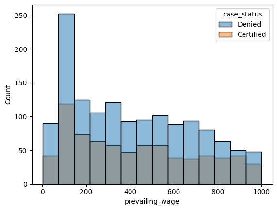

```python
#create a dataframe only of workers applying for jobs with a *unit_wage* of 'Hour'
df_hourly = df[df.unit_of_wage=='Hour']
#show a distribution of the *prevailing_wage* within this dataframe, along with the ratio of *case_status* within each bin
sns.histplot(data=df_hourly, x='prevailing_wage', hue='case_status')
plt.show()
```

```python
#create bins that categorize applicants by the per-day wage of the job he or she is applying for
bins = list(np.arange(0,1100,200))
#assign each applicant to a category
df_hourly['income_per_day'] = pd.cut(df_hourly['prevailing_wage'], bins)
df_hourly.groupby('income_per_day')['case_status'].value_counts()
```

| income_per_day | case_status | count |
| --- | --- | --- |
| (0, 200] | Denied | 448 |
|  | Certified | 219 |
| (200, 400] | Denied | 301 |
|  | Certified | 166 |
| (400, 600] | Denied | 274 |
|  | Certified | 144 |
| (600, 800] | Denied | 239 |
|  | Certified | 116 |
| (800, 1000] | Denied | 148 |
|  | Certified | 102 |

**dtype:** int64

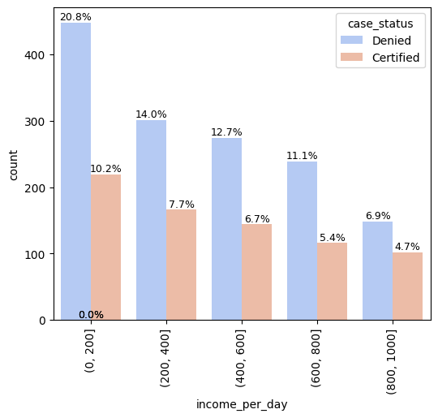

```python
#create a plot of the data above, but additionally with the percent of each group within the total number of cases
labeled_barplot(df_hourly,'income_per_day','case_status',perc=True,order=None)
```

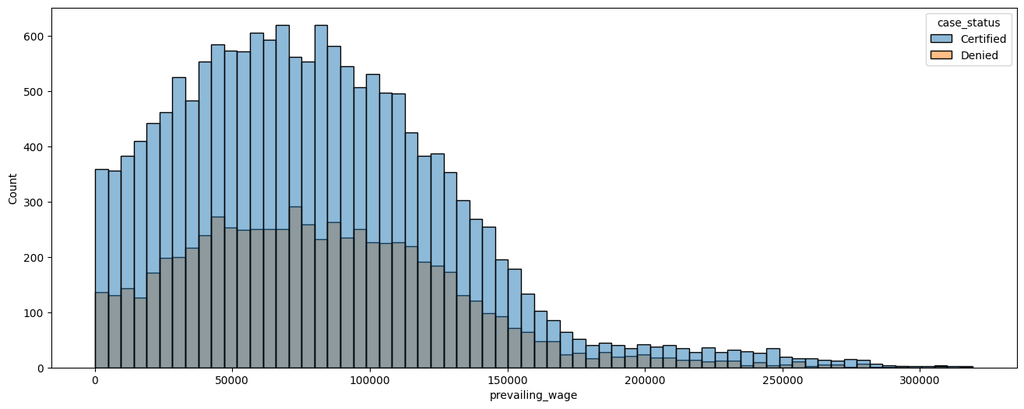

```python
#create a new dataframe of only those applicants applying for jobs with annual salaries (i.e., not 'Hour')
df_annual = df[df.unit_of_wage != "Hour"]
#show the distribution of annual salaries, along with ratio of *case_status* within each bin
plt.figure(figsize=(16,6))
sns.histplot(data=df_annual, x='prevailing_wage', hue='case_status')
plt.show()
```

```python
#create bins to categorize a job by its annual salary, which indicates how well paying the job is
bins = [0,25000,50000,75000,100000,125000,np.inf]
names = ['$0-25k','$25k-50k','$50k-75k','$75k-100k','$100k-125k','$125k+']
#assign an applicant to a category
df_annual['income_per_year'] = pd.cut(df_annual['prevailing_wage'], bins, labels=names)
df_annual.groupby('income_per_year')['case_status'].value_counts()
```

| income_per_year | case_status | count |
| --- | --- | --- |
| $0-25k | Certified | 2090 |
|  | Denied | 761 |
| $25k-50k | Certified | 2839 |
|  | Denied | 1237 |
| $50k-75k | Certified | 3133 |
|  | Denied | 1372 |
| $75k-100k | Certified | 3014 |
|  | Denied | 1318 |
| $100k-125k | Certified | 2410 |
|  | Denied | 1138 |
| $125k+ | Certified | 2785 |
|  | Denied | 1226 |

**dtype:** int64

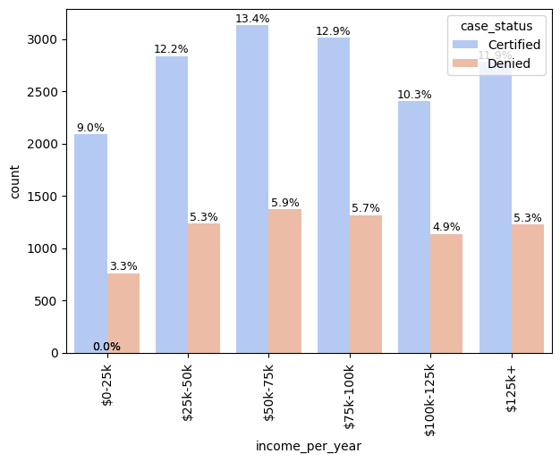

```python
#create a plot of the data above, but additionally with the percent of each group within the total number of cases
labeled_barplot(df_annual,'income_per_year','case_status',perc=True,order=None)
```

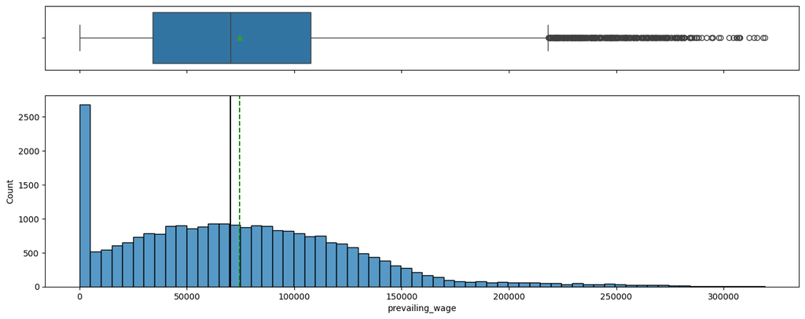

```python
histogram_boxplot(df,  "prevailing_wage", figsize=(16, 6), kde=False, bins=None, hue=None)
```

- In support of the observation above, there does not appear to be a significant change in ratio of approved to denied applications as income_per_year increases. To the contrary, the ratio may actually decrease as this prevailing_wage increases.
- For applications for jobs with an income_per_year wage, the highest concentration of applications is for jobs with 50,000 to 75,000 dollars per year in salary.

### **Univariate Analysis**

**Observation on no of yr_of_estab**

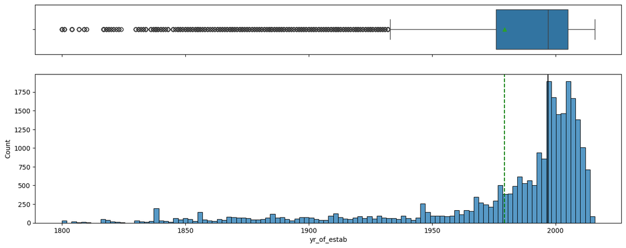

```python
histogram_boxplot(df, "yr_of_estab")
```

**Observation on no of prevailing_wage**

```python
df_annual.describe().T
```

|  | count | mean | std | min | 25% | 50% | 75% | max |
| --- | --- | --- | --- | --- | --- | --- | --- | --- |
| no_of_employees | 23323.0 | 5800.707156 | 23478.022172 | -26.0 | 1036.000 | 2144.00 | 3560.000 | 602069.00 |
| yr_of_estab | 23323.0 | 1979.915448 | 41.990619 | 1800.0 | 1977.000 | 1997.00 | 2005.000 | 2016.00 |
| prevailing_wage | 23323.0 | 81303.431257 | 49935.898618 | 100.0 | 43843.775 | 76258.47 | 111414.395 | 319210.27 |

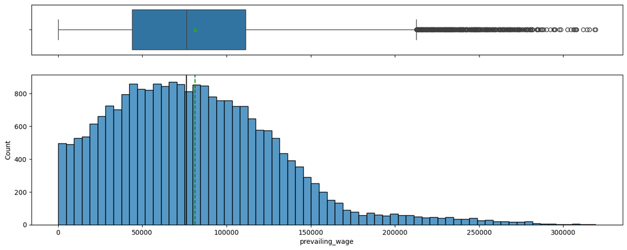

```python
histogram_boxplot(df_annual, "prevailing_wage")
```

```python
df_hourly.describe().T
```

|  | count | mean | std | min | 25% | 50% | 75% | max |
| --- | --- | --- | --- | --- | --- | --- | --- | --- |
| no_of_employees | 2157.0 | 4221.774687 | 14847.427144 | -26.0000 | 877.0000 | 1836.0000 | 2974.0000 | 288512.0000 |
| yr_of_estab | 2157.0 | 1973.943904 | 45.896877 | 1807.0000 | 1968.0000 | 1993.0000 | 2003.0000 | 2016.0000 |
| prevailing_wage | 2157.0 | 414.570513 | 275.015000 | 2.1367 | 152.7003 | 372.6523 | 637.3111 | 999.9195 |

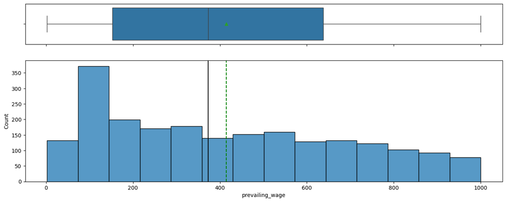

```python
histogram_boxplot(df_hourly, "prevailing_wage")
```